# Text Prediction Model: Exploratory Data Analysis

Understanding Word Patterns for Next-Word Prediction

Kernel236

2025-10-24

# Project Goal

This project aims to build a **text prediction application** that suggests the next word as users type, similar to smartphone keyboard predictions. This report documents the exploratory analysis of the training data and outlines the strategy for building the prediction algorithm.

## Development Approach

This project is supported by **Rcaptext**, a custom R package developed specifically for this capstone project. The package provides optimized functions for:

- 📚 **Corpus loading and management** - Efficient handling of large text datasets
- 🧹 **Text preprocessing** - Standardized cleaning and tokenization
- ✂️ **N-gram extraction** - Fast tokenization of unigrams, bigrams, and trigrams
- 📊 **Frequency analysis** - Statistical analysis of term distributions
- 📈 **Visualization tools** - Custom plotting functions for text analysis

> 💡 **Note**: Rcaptext is being actively developed alongside this project, with functions designed specifically for natural language processing tasks in the context of predictive text modeling.

# Data Overview

## Dataset Description

The analysis uses the **English US text corpus** from three different sources:

- 📰 **News articles**: Formal, structured language
- 📝 **Blog posts**: Semi-formal, diverse topics
- 🐦 **Twitter messages**: Informal, conversational language

This diversity ensures our prediction model works well across different writing styles.

## Data Loading and Preprocessing

✅ **Data successfully loaded and cleaned**

For computational efficiency, this analysis uses a **5% stratified sample** of the full corpus, maintaining proportional representation from each source.

```r
knitr::kable(sample_composition,
             caption = "Sample distribution across text sources",
             col.names = c("Source", "Number of Documents"),
             format.args = list(big.mark = ","))
```

Sample distribution across text sources

| Source | Number of Documents |
| --- | --- |
| blogs | 44,873 |
| news | 50,490 |
| twitter | 117,992 |

# Understanding Word Patterns

## What are N-grams?

To predict the next word, we need to understand how words appear together in text:

- **Unigrams**: Individual words (e.g., “the”, “happy”, “cat”)
- **Bigrams**: Two-word sequences (e.g., “the cat”, “very happy”)
- **Trigrams**: Three-word sequences (e.g., “the black cat”, “very happy person”)

By analyzing the frequency of these patterns, we can predict what word is likely to come next.

## Frequency Analysis

```r
# Generate n-grams from the cleaned corpus sample
# This chunk is cached to avoid re-tokenization on each knit
uni <- tokenize_unigrams(small, text_col = "text_clean")   # Individual words
bi  <- tokenize_bigrams(small,  text_col = "text_clean")   # Word pairs
tri <- tokenize_trigrams(small, text_col = "text_clean")   # Word triplets

# Calculate frequency distributions for each n-gram type
freq_uni <- freq_unigrams(uni)    # Returns: word, n (count), p (probability)
freq_bi  <- freq_bigrams(bi)      # Returns: combined word pair, n, p
freq_tri <- freq_trigrams(tri)    # Returns: combined word triplet, n, p

# Analyze coverage requirements at 50% and 90% thresholds
cov_uni <- coverage_from_freq(freq_uni, thresholds = c(0.5, 0.9), name_col = "word")$summary |>
  dplyr::mutate(type = "unigrams")
cov_bi  <- coverage_from_freq(freq_bi,  thresholds = c(0.5, 0.9))$summary |>
  dplyr::mutate(type = "bigrams")
cov_tri <- coverage_from_freq(freq_tri, thresholds = c(0.5, 0.9))$summary |>
  dplyr::mutate(type = "trigrams")

# Create comparative coverage table
coverage_table <- dplyr::bind_rows(cov_uni, cov_bi, cov_tri) |>
  dplyr::select(type, threshold, n_unique) |>
  tidyr::pivot_wider(names_from = threshold, values_from = n_unique, names_prefix = "cov_")

# Display results with interpretation
knitr::kable(coverage_table,
             caption = "Vocabulary size needed to capture text patterns",
             col.names = c("Pattern Type", "50% Coverage", "90% Coverage"),
             format.args = list(big.mark = ","))
```

Vocabulary size needed to capture text patterns

| Pattern Type | 50% Coverage | 90% Coverage |
| --- | --- | --- |
| unigrams | 140 | 6,951 |
| bigrams | 36,519 | 1,045,664 |
| trigrams | 1,044,809 | 2,887,361 |

### What This Means

# Key Findings from the Data

## 1. Most Common Words

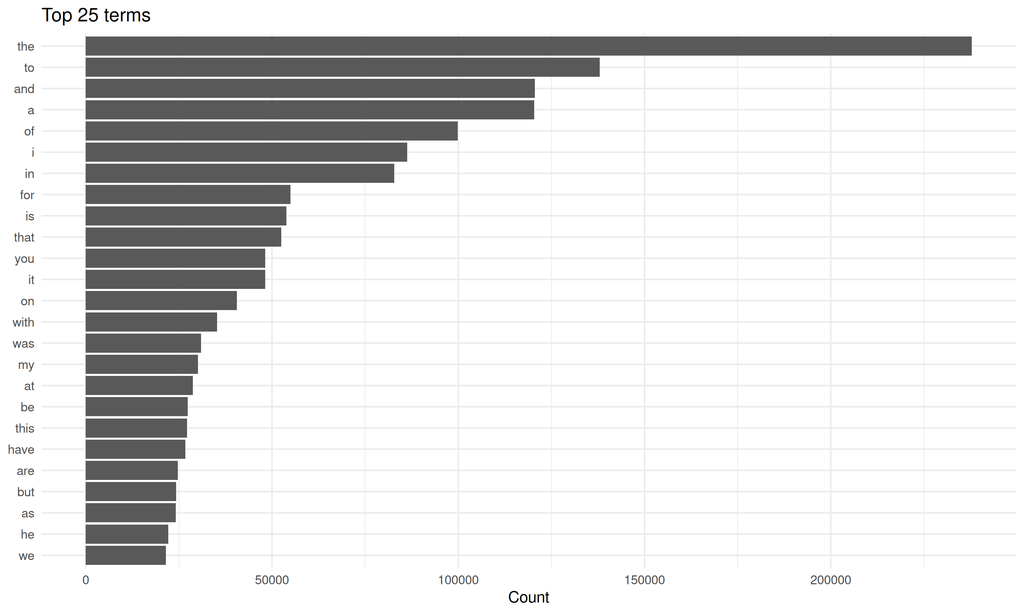

Top 25 most frequent words in the corpus

```r
plot_top_terms(freq_uni, top = 25, name_col = "word")
```

**Finding**: The most common words are mostly function words like “the”, “to”, “and” - this is expected and important for natural predictions.

## 2. Word Frequency Distribution

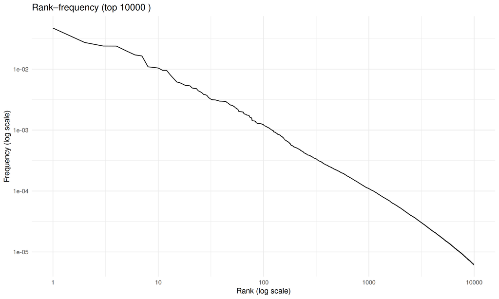

How word frequency decreases with rank

```r
plot_rank_frequency(freq_uni, top = 10000, name_col = "word", p_col = "p")
```

**Finding**: This graph shows a fundamental pattern in language - a few words are very common, while most words are rare. This pattern (called Zipf’s Law) helps us optimize our prediction model.

## 3. Coverage Efficiency

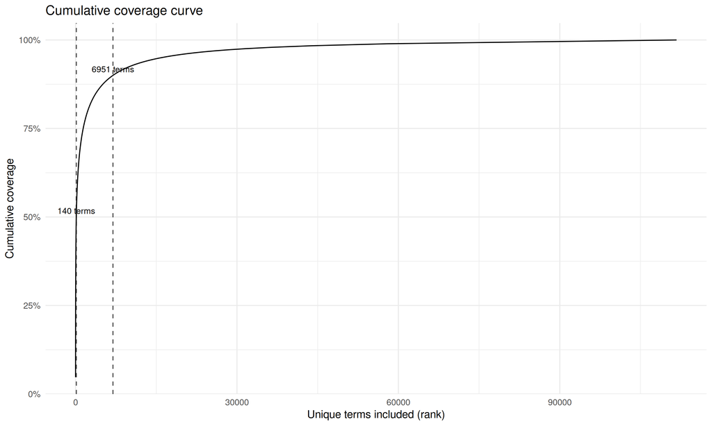

How quickly we achieve text coverage

```r
plot_cumulative_coverage_with_marks(freq_uni, thresholds = c(0.5, 0.9))
```

**Finding**: Just a small vocabulary of the most common words covers a large portion of typical text. This means our app can be efficient - we don’t need to store every possible word to make good predictions.

## 4. Word Combinations Matter

### Common Two-Word Phrases

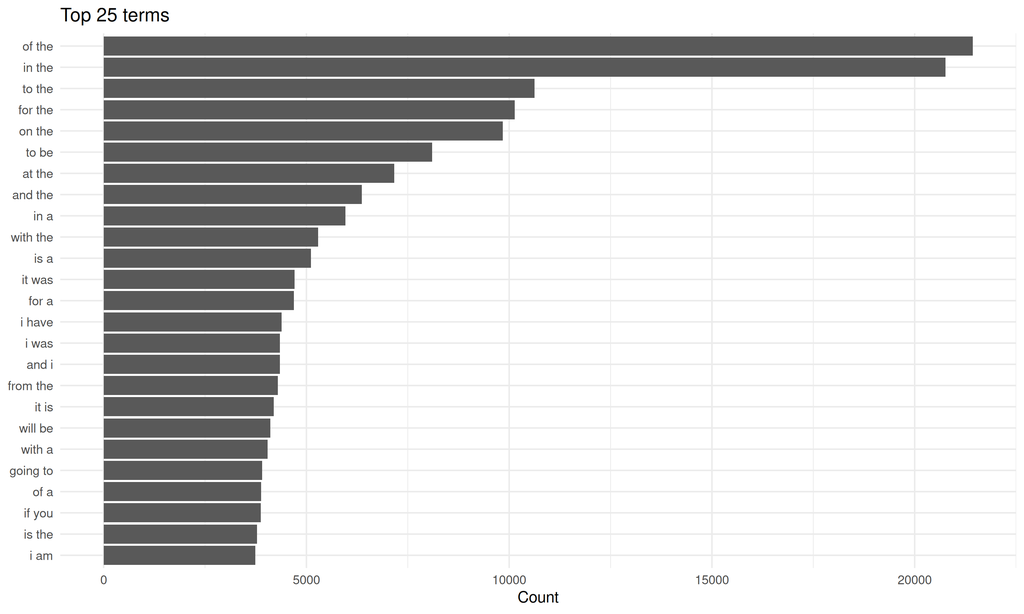

Most frequent two-word combinations

```r
plot_top_terms(freq_bi, top = 25, name_col = "word")
```

**Finding**: Looking at word pairs like “of the” and “in the” shows us natural language patterns that improve predictions beyond just looking at single words.

### Common Three-Word Phrases

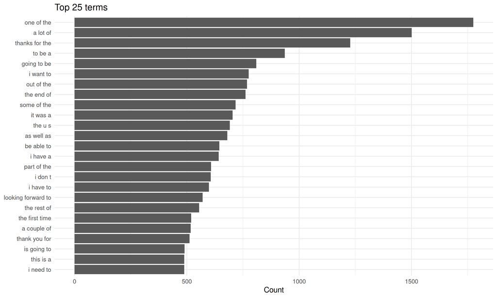

Most frequent three-word combinations

```r
plot_top_terms(freq_tri, top = 25, name_col = "word")
```

**Finding**: Three-word sequences capture even more context, but they’re less common. This is why our model needs a smart fallback strategy.

## 5. Comparing Pattern Complexity

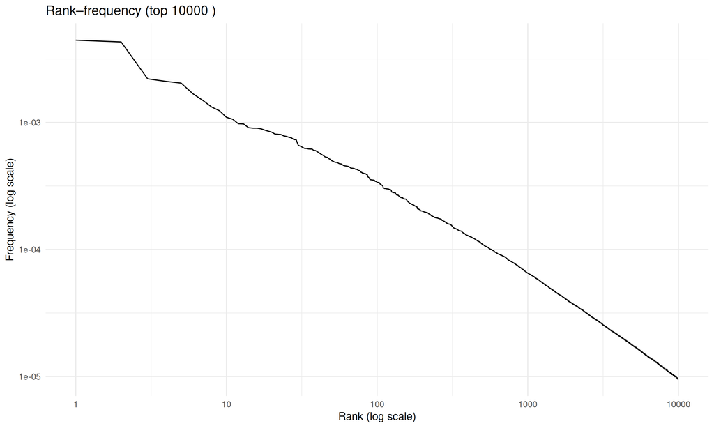

Two-word combination frequencies

```r
plot_rank_frequency(freq_bi, top = 10000, name_col = "word", p_col = "p")
```

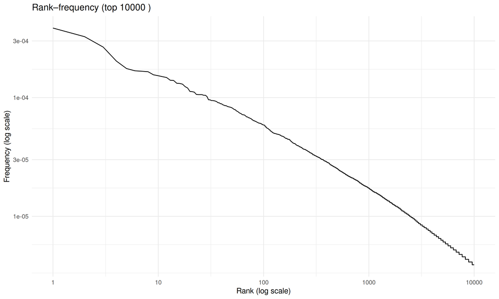

Three-word combination frequencies

```r
plot_rank_frequency(freq_tri, top = 10000, name_col = "word", p_col = "p")
```

**Finding**: As we move from single words to word pairs to triplets, patterns become more specific but also rarer. This confirms we need a flexible prediction strategy.

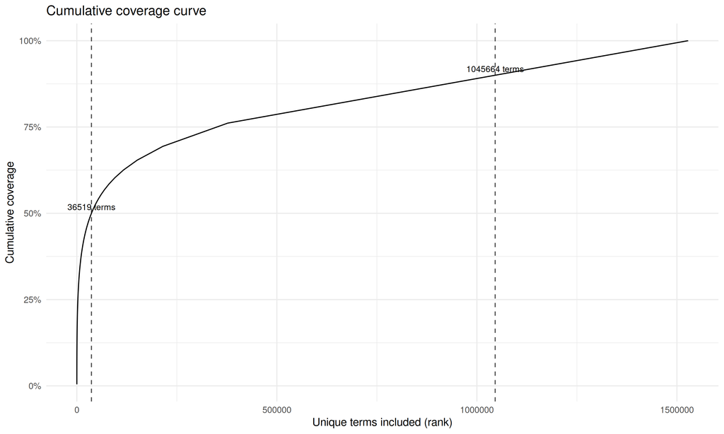

Coverage analysis for two-word combinations

```r
plot_cumulative_coverage_with_marks(freq_bi, thresholds = c(0.5, 0.9))
```

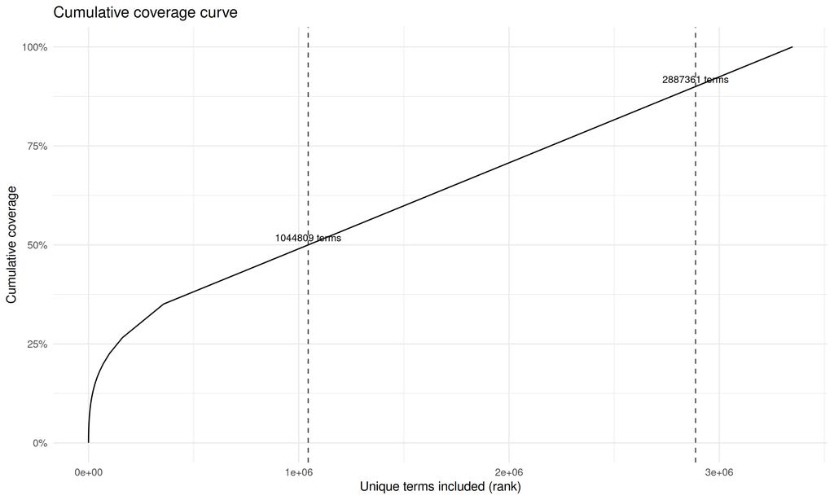

Coverage analysis for three-word combinations

```r
plot_cumulative_coverage_with_marks(freq_tri, thresholds = c(0.5, 0.9))
```

# Plans for the Prediction Algorithm

## Algorithm Strategy

Based on the exploratory analysis, the prediction algorithm will use a **back-off model**:

1. **First Try**: Look for matching three-word sequences (trigrams) - these give the most accurate predictions
2. **Second Try**: If no trigram match, fall back to two-word sequences (bigrams)
3. **Final Fallback**: If still no match, use single-word frequencies (unigrams)

This approach balances accuracy (from longer sequences) with coverage (from shorter sequences).

## Model Optimization

The analysis revealed important optimization opportunities:

- 🎯 **Focus on common patterns**: 50% of text is covered by relatively few word combinations
- 💾 **Memory efficiency**: We can prune rare patterns while maintaining good coverage
- ⚡ **Speed**: Pre-computing and indexing frequent patterns will enable fast predictions

## Planned Shiny App Features

The final application will include:

1. **Text Input Box**: Users type their text
2. **Live Predictions**: Top 3-5 word suggestions update as user types
3. **Confidence Indicator**: Visual feedback on prediction confidence
4. **Simple Interface**: Clean, responsive design for easy use
5. **Performance Stats**: Display prediction speed and accuracy

## Technical Implementation

- **Language**: R with Shiny framework
- **Core Engine**: Custom Rcaptext package for text processing and n-gram analysis
- **Data Structure**: Optimized lookup tables for fast n-gram matching
- **Algorithm**: Stupid back-off smoothing for handling unseen combinations
- **Deployment**: Shiny server or shinyapps.io for web access

## Next Steps

1. Build complete n-gram frequency tables from full dataset using Rcaptext
2. Implement back-off prediction algorithm
3. Optimize for speed and memory usage
4. Create interactive Shiny interface
5. Test with real users and refine

**Report generated**: 2025-10-24  
**Data source**: SwiftKey English US corpus (blogs, news, Twitter)  
**Analysis powered by**: Custom Rcaptext R package (developed for this capstone project)